# Lab7

Annie Adams

2023-03-01

## Case Study: Eel Distribution Modeling

This week’s lab follows a project modeling the eel species Anguilla australis described by Elith et al. (2008). There are two data sets for this lab. You’ll use one for training and evaluating your model, and you’ll use your model to make predictions predictions on the other. Then you’ll compare your model’s performance to the model used by Elith et al.

## Data

Grab the training data sets (eel.model.data.csv, eel.eval.data.csv) from github here: https://github.com/MaRo406/eds-232-machine-learning/blob/main/data

```r
set.seed(11)
library("tidymodels")
library("tidyverse")
library("dplyr")
eel_eval <- read_csv(file = "https://raw.githubusercontent.com/MaRo406/eds-232-machine-learning/main/data/eel.eval.data.csv") %>% rename(Angaus = Angaus_obs) %>% mutate(Angaus = as.factor(Angaus))
eel_model <- read_csv(file = "https://raw.githubusercontent.com/MaRo406/eds-232-machine-learning/main/data/eel.model.data.csv")%>%
  mutate(Angaus = as.factor(Angaus)) %>%
  select(-Site)
```

### Split and Resample

Split the model data (eel.model.data.csv) into a training and test set, stratified by outcome score (Angaus). Use 10-fold CV to resample the training set.

```r
#split model data into train and test stratified by outcome score
data_split = initial_split(eel_model, strata = Angaus)

train = training(data_split)#get training data
test = testing(data_split) #get testing data

cv_folds = train %>% vfold_cv( v = 10, strata = Angaus) #10 fold cv to resample
```

### Preprocess

Create a recipe to prepare your data for the XGBoost model

```r
eel_recipe = recipe(Angaus ~ ., data = train) %>% #create model recipe
  step_dummy(all_nominal_predictors()) %>% #create dummy variables from all factors
  step_normalize(all_numeric_predictors()) #normalize all numeric predictors
```

## Tuning XGBoost

### Tune Learning Rate

Following the XGBoost tuning strategy outlined in lecture, first we conduct tuning on just the learning rate parameter:

1. Create a model specification using {xgboost} for the estimation
- Only specify one parameter to tune()

```r
boost_model <- boost_tree(learn_rate = tune(), trees = 3000) %>%
  set_engine("xgboost") %>%
  set_mode("classification")


boost_workflow = workflow() %>%
  add_model(boost_model) %>%
  add_recipe(eel_recipe)

boost_workflow
```

```
## ══ Workflow ════════════════════════════════════════════════════════════════════
## Preprocessor: Recipe
## Model: boost_tree()
##
## ── Preprocessor ────────────────────────────────────────────────────────────────
## 2 Recipe Steps
##
## • step_dummy()
## • step_normalize()
##
## ── Model ───────────────────────────────────────────────────────────────────────
## Boosted Tree Model Specification (classification)
##
## Main Arguments:
##   trees = 3000
##   learn_rate = tune()
##
## Computational engine: xgboost
```

2. Set up a grid to tune your model by using a range of learning rate parameter values: expand.grid(learn_rate = seq(0.0001, 0.3, length.out = 30))
- Use appropriate metrics argument(s) - Computational efficiency becomes a factor as models get more complex and data get larger. Record the time it takes to run. Do this for each tuning phase you run.You could use {tictoc} or Sys.time().

```r
grid <- expand.grid(learn_rate = seq(0.0001, 0.3, length.out = 30))
system.time(
    boost_rs <- boost_workflow %>% tune_grid(
      resamples = cv_folds,
      grid = grid,
      metrics = metric_set(accuracy, roc_auc, pr_auc))
)
```

```
##    user  system elapsed
## 354.776   5.076 362.389
```

3. Show the performance of the best models and the estimates for the learning rate parameter values associated with each.

```r
show_best(boost_rs, metric = "roc_auc")
```

```
## # A tibble: 5 × 7
##   learn_rate .metric .estimator  mean     n std_err .config
##        <dbl> <chr>   <chr>      <dbl> <int>   <dbl> <chr>
## 1     0.0104 roc_auc binary     0.857    10  0.0136 Preprocessor1_Model02
## 2     0.0725 roc_auc binary     0.856    10  0.0160 Preprocessor1_Model08
## 3     0.0208 roc_auc binary     0.856    10  0.0133 Preprocessor1_Model03
## 4     0.0415 roc_auc binary     0.854    10  0.0155 Preprocessor1_Model05
## 5     0.0311 roc_auc binary     0.854    10  0.0143 Preprocessor1_Model04
```

### Tune Tree Parameters

1. Create a new specification where you set the learning rate (which you already optimized) and tune the tree parameters.

```r
boost_model_update <- boost_tree( learn_rate = select_best(boost_rs, metric = "roc_auc")$learn_rate, trees = 3000, min_n = tune(), tree_depth = tune(), loss_reduction = tune()) %>%
  set_engine("xgboost") %>%
  set_mode("classification")

boost_update_workflow = workflow() %>%
  add_model(boost_model_update) %>%
  add_recipe(eel_recipe)
```

2. Set up a tuning grid. This time use grid_latin_hypercube() to get a representative sampling of the parameter space

```r
grid2 <- grid_latin_hypercube( min_n(), tree_depth(), loss_reduction(), size = 50)
system.time(
    boost_rs_update <- tune_grid(
      object = boost_update_workflow,
      resamples = cv_folds,
      grid = grid2,
      metrics = metric_set(accuracy, roc_auc, pr_auc)
)
)
```

```
##    user  system elapsed
## 497.242   6.772 506.881
```

3. Show the performance of the best models and the estimates for the tree parameter values associated with each.

```r
show_best(boost_rs_update, metric = "roc_auc")
```

```
## # A tibble: 5 × 9
##   min_n tree_depth loss_reduction .metric .estimator  mean     n std_err .config
##   <int>      <int>          <dbl> <chr>   <chr>      <dbl> <int>   <dbl> <chr>
## 1     3         11       9.95e- 8 roc_auc binary     0.851    10  0.0129 Prepro…
## 2     6          2       2.52e- 3 roc_auc binary     0.850    10  0.0179 Prepro…
## 3     4          7       1.74e-10 roc_auc binary     0.848    10  0.0153 Prepro…
## 4     5         11       1.94e- 6 roc_auc binary     0.847    10  0.0153 Prepro…
## 5     4          7       8.17e- 3 roc_auc binary     0.845    10  0.0148 Prepro…
```

### Tune Stochastic Parameters

1. Create a new specification where you set the learning rate and tree parameters (which you already optimized) and tune the stochastic parameters.

```r
boost_model_update2 <- boost_tree(
  learn_rate = select_best(boost_rs, metric = "roc_auc")$learn_rate,
  trees = 3000,
  min_n = select_best(boost_rs_update, metric = "roc_auc")$min_n,
  tree_depth = select_best(boost_rs_update, metric = "roc_auc")$tree_depth,
  loss_reduction = select_best(boost_rs_update, metric = "roc_auc")$loss_reduction,
  stop_iter = tune(), mtry = tune(), sample_size = tune()) %>%
  set_engine("xgboost") %>%
  set_mode("classification")

boost_update_workflow2 = workflow() %>%
  add_model(boost_model_update2) %>%
  add_recipe(eel_recipe)
```

2. Set up a tuning grid. Use grid_latin_hypercube() again.

```r
grid3 <- grid_latin_hypercube( stop_iter(), sample_size = sample_prop(c(0.4,0.9)), finalize(mtry(), select(train, -Angaus)),
  size = 50)
system.time(
    boost_rs_update2 <- tune_grid(
      boost_update_workflow2,
      resamples = cv_folds,
      grid = grid3,
      metrics = metric_set(accuracy, roc_auc, pr_auc)
)
)
```

```
##     user   system  elapsed
##  664.058    9.930 1423.349
```

3. Show the performance of the best models and the estimates for the tree parameter values associated with each.

```r
show_best(boost_rs_update2)
```

```
## # A tibble: 5 × 9
##    mtry sample_size stop_iter .metric  .estimator  mean     n std_err .config
##   <int>       <dbl>     <int> <chr>    <chr>      <dbl> <int>   <dbl> <chr>
## 1     1       0.752        13 accuracy binary     0.842    10 0.0105  Preproces…
## 2    12       0.821         9 accuracy binary     0.842    10 0.0118  Preproces…
## 3     1       0.732        11 accuracy binary     0.842    10 0.00873 Preproces…
## 4    11       0.644         4 accuracy binary     0.841    10 0.0125  Preproces…
## 5     7       0.511        18 accuracy binary     0.841    10 0.0121  Preproces…
```

## Finalize workflow and make final prediction

1. How well did your model perform? What types of errors did it make?

```r
final_boost <- boost_tree(
  learn_rate = select_best(boost_rs, metric = "roc_auc")$learn_rate,
  trees = 3000,
  min_n = select_best(boost_rs_update, metric = "roc_auc")$min_n,
  tree_depth = select_best(boost_rs_update, metric = "roc_auc")$tree_depth,
  loss_reduction = select_best(boost_rs_update, metric = "roc_auc")$loss_reduction,
  stop_iter = select_best(boost_rs_update2, metric = "roc_auc")$stop_iter, mtry = select_best(boost_rs_update2, metric = "roc_auc")$mtry, sample_size =select_best(boost_rs_update2, metric = "roc_auc")$sample_size) %>%
  set_engine("xgboost") %>%
  set_mode("classification")
final_boost
```

```
## Boosted Tree Model Specification (classification)
##
## Main Arguments:
##   mtry = select_best(boost_rs_update2, metric = "roc_auc")$mtry
##   trees = 3000
##   min_n = select_best(boost_rs_update, metric = "roc_auc")$min_n
##   tree_depth = select_best(boost_rs_update, metric = "roc_auc")$tree_depth
##   learn_rate = select_best(boost_rs, metric = "roc_auc")$learn_rate
##   loss_reduction = select_best(boost_rs_update, metric = "roc_auc")$loss_reduction
##   sample_size = select_best(boost_rs_update2, metric = "roc_auc")$sample_size
##   stop_iter = select_best(boost_rs_update2, metric = "roc_auc")$stop_iter
##
## Computational engine: xgboost
```

```r
final_boost_update_workflow = workflow() %>%
  add_model(final_boost) %>%
  add_recipe(eel_recipe)


final_fit <- last_fit(final_boost_update_workflow, data_split)

collect_metrics(final_fit)
```

```
## # A tibble: 2 × 4
##   .metric  .estimator .estimate .config
##   <chr>    <chr>          <dbl> <chr>
## 1 accuracy binary         0.841 Preprocessor1_Model1
## 2 roc_auc  binary         0.874 Preprocessor1_Model1
```

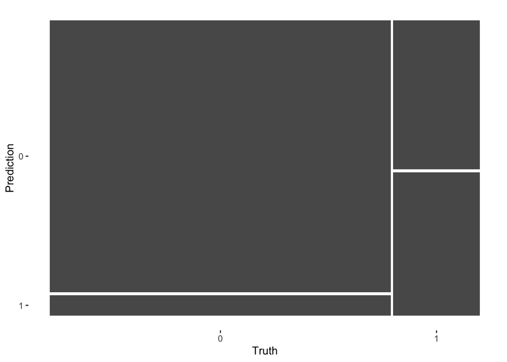

```r
preds <- final_fit$.predictions[[1]]
confusion_matrix <- preds %>% conf_mat(truth=Angaus, estimate=.pred_class)
autoplot(confusion_matrix)
```

```r
accuracy_calculation <- confusion_matrix %>%
  summary() %>%
  filter(.metric == "accuracy")

accuracy_value <- accuracy_calculation$.estimate

accuracy_value
```

```
## [1] 0.8406375
```

## Fit your model the evaluation data and compare performance

1. Now used your final model to predict on the other dataset (eval.data.csv)

```r
eval_fit<- fit(final_boost_update_workflow, eel_eval)
eval_preds <- predict(eval_fit, eel_eval) %>%
  bind_cols(eel_eval$Angaus)
```

2. How does your model perform on this data?

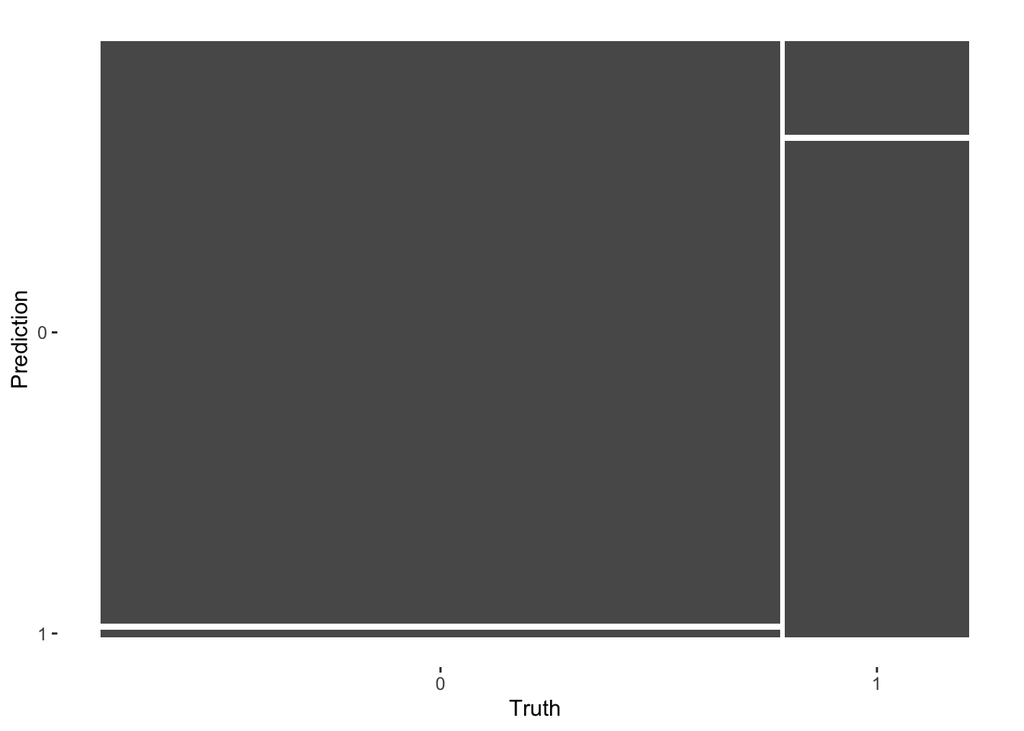

```r
confusion_matrix <- eval_preds %>% conf_mat(truth=...2, estimate=.pred_class)
autoplot(confusion_matrix)
```

```r
accuracy_calculation <- confusion_matrix %>%
  summary() %>%
  filter(.metric == "accuracy")

accuracy_value_eval <- accuracy_calculation$.estimate

accuracy_value_eval
```

```
## [1] 0.956
```

**This model seems to predict a bit better than the last. Similarly to the previous model, there are far less false positives than false negatives. However, this time there are also far less false negatives than the previous model.This model achieved an accuracy of .956, which is better than an accuracy of .841.**

3. How do your results compare to those of Elith et al.?
- Use {vip} to compare variable importance
- What do your variable importance results tell you about the distribution of this eel species?

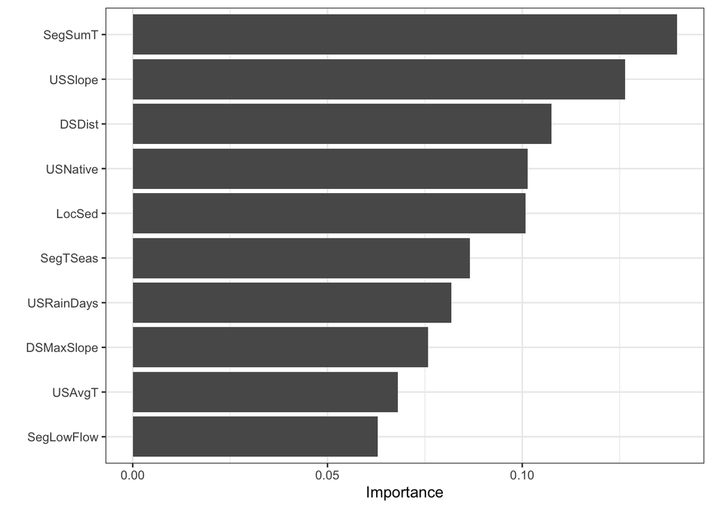

```r
eval_fit %>%
  vip::vip(geom = "col") +
  theme_bw()
```

The variable importance results I got were similar to those of Elith at all. The study in the paper found that SegSumT, USNative, Method, and DSDIST were the top four important variables. I also got that SegSumT, DSDist, and USNative were in the top four variables in terms of importance. The paper received a cross validation predictive performance score of .869. This is slightly better than the accuracy I received of .841.

The variable importance plot shows me that summer air temperature, average slop in upstream catchement,and distance to the coast all effect the outcome on Angaus detection the most.